# 1. Introduction to GDS Format

This tutorial introduces Genomic Data Structure (GDS), which is a storage format that can efficiently store genomic data and provide fast random access to subsets of the data. For more information on GDS for sequence data, see the [SeqArray package vignette](https://github.com/zhengxwen/SeqArray/blob/master/vignettes/SeqArrayTutorial.Rmd).

## Convert a VCF to GDS

To use the R packages developed at the University of Washington Genetic Analysis Center for sequence data, we first need to convert a VCF file to GDS. (If the file is BCF, use https://samtools.github.io/bcftools/bcftools.html to convert to VCF.)

```r
library(SeqArray)
repo_path <- "https://github.com/UW-GAC/SISG_2022/raw/main"
if (!dir.exists("data")) dir.create("data")

# file path to the VCF file to *read* data from
vcffile <- "data/1KG_phase3_subset_chr1.vcf.gz"
if (!file.exists(vcffile)) download.file(file.path(repo_path, vcffile), vcffile)

# file path to *write* the output GDS file to
gdsfile <- "data/1KG_phase3_subset_chr1.gds"

# convert the VCF to GDS
seqVCF2GDS(vcffile, gdsfile, fmt.import="GT", storage.option="LZMA_RA")
```

```
## Thu Jul  6 20:49:50 2023
## Variant Call Format (VCF) Import:
##     file(s):
##         1KG_phase3_subset_chr1.vcf.gz (120.7K)
##     file format: VCFv4.1
##     genome reference: ftp://ftp.1000genomes.ebi.ac.uk//vol1/ftp/technical/reference/phase2_reference_assembly_sequence/hs37d5.fa.gz
##     the number of sets of chromosomes (ploidy): 2
##     the number of samples: 1,126
##     genotype storage: bit2
##     compression method: LZMA_RA
##     # of samples: 1126
## Output:
##     data/1KG_phase3_subset_chr1.gds
## Parsing '1KG_phase3_subset_chr1.vcf.gz':
## + genotype/data   { Bit2 2x1126x1121 LZMA_ra(0.01%), 42B }
## Digests:
##     sample.id  [md5: 6b04799356320063276ad84f70713429]
##     variant.id  [md5: 35a6feaa59ff5659e2d16d2afb6923d4]
##     position  [md5: 868601c0a2f333d113be2040295602b4]
##     chromosome  [md5: 774667f087db893e987ce02dc9188ee2]
##     allele  [md5: bb36e628c2faf01dfc2792615b6c2350]
##     genotype  [md5: 59be1f80c30eee4a93b82077530eba87]
##     phase  [md5: ae6a90ef5cceae947052b0c8999a4a94]
##     annotation/id  [md5: 045802d7856c955f4710288e4764fcbe]
##     annotation/qual  [md5: d6b8ed9bd5cac7dd7898bb679675fc7c]
##     annotation/filter  [md5: 8294edaf60fffc1e9aa693b4bc423dd1]
## Done.
## Thu Jul  6 20:49:50 2023
## Optimize the access efficiency ...
## Clean up the fragments of GDS file:
##     open the file 'data/1KG_phase3_subset_chr1.gds' (71.3K)
##     # of fragments: 123
##     save to 'data/1KG_phase3_subset_chr1.gds.tmp'
##     rename 'data/1KG_phase3_subset_chr1.gds.tmp' (70.5K, reduced: 744B)
##     # of fragments: 61
## Thu Jul  6 20:49:50 2023
```

## Exploring a GDS File

#### Open a GDS

We can interact with the GDS file using the [SeqArray R package](https://bioconductor.org/packages/release/bioc/html/SeqArray.html). The first thing we need to do is open a connection to a GDS file on disk using the `seqOpen` function.

```r
# open a connection to the GDS file
gds <- seqOpen(gdsfile)
gds
```

```
## Object of class "SeqVarGDSClass"
## File: /Users/mconomos/Documents/Teaching/SISG_2023/data/1KG_phase3_subset_chr1.gds (70.5K)
## +    [  ] *
## |--+ description   [  ] *
## |--+ sample.id   { Str8 1126 LZMA_ra(9.66%), 877B } *
## |--+ variant.id   { Int32 1120 LZMA_ra(17.5%), 793B } *
## |--+ position   { Int32 1120 LZMA_ra(78.5%), 3.4K } *
## |--+ chromosome   { Str8 1120 LZMA_ra(4.55%), 109B } *
## |--+ allele   { Str8 1120 LZMA_ra(26.0%), 1.2K } *
## |--+ genotype   [  ] *
## |  |--+ data   { Bit2 2x1126x1121 LZMA_ra(8.34%), 51.4K } *
## |  |--+ extra.index   { Int32 3x0 LZMA_ra, 18B } *
## |  \--+ extra   { Int16 0 LZMA_ra, 18B }
## |--+ phase   [  ]
## |  |--+ data   { Bit1 1126x1120 LZMA_ra(0.11%), 177B } *
## |  |--+ extra.index   { Int32 3x0 LZMA_ra, 18B } *
## |  \--+ extra   { Bit1 0 LZMA_ra, 18B }
## |--+ annotation   [  ]
## |  |--+ id   { Str8 1120 LZMA_ra(40.4%), 3.6K } *
## |  |--+ qual   { Float32 1120 LZMA_ra(2.46%), 117B } *
## |  |--+ filter   { Int32,factor 1120 LZMA_ra(2.46%), 117B } *
## |  |--+ info   [  ]
## |  \--+ format   [  ]
## \--+ sample.annotation   [  ]
```

#### Reading Data

The `seqGetData` function is the basic function for reading in data from a GDS file

```r
# the unique sample identifier comes from the VCF header
sample.id <- seqGetData(gds, "sample.id")
length(sample.id)
```

```
## [1] 1126
```

```r
head(sample.id)
```

```
## [1] "HG00096" "HG00097" "HG00099" "HG00100" "HG00101" "HG00102"
```

```r
# a unique integer ID is assigned to each variant
variant.id <- seqGetData(gds, "variant.id")
length(variant.id)
```

```
## [1] 1120
```

```r
head(variant.id)
```

```
## [1] 1 2 3 4 5 6
```

```r
chr <- seqGetData(gds, "chromosome")
head(chr)
```

```
## [1] "1" "1" "1" "1" "1" "1"
```

```r
pos <- seqGetData(gds, "position")
head(pos)
```

```
## [1]  970546  985900 1025045 1265550 1472676 1735725
```

```r
id <- seqGetData(gds, "annotation/id")
head(id)
```

```
## [1] ""           "rs17160776" ""           ""           "rs78293298"
## [6] ""
```

There are additional useful functions for summary level data.

```r
# minor allele frequency of each variant
maf <- seqAlleleFreq(gds, minor = TRUE)
head(maf)
```

```
## [1] 0.0039964476 0.0492895204 0.0004440497 0.0008880995 0.0071047957
## [6] 0.0022202487
```

```r
summary(maf)
```

```
##     Min.  1st Qu.   Median     Mean  3rd Qu.     Max.
## 0.000000 0.000444 0.001332 0.037846 0.012877 0.498668
```

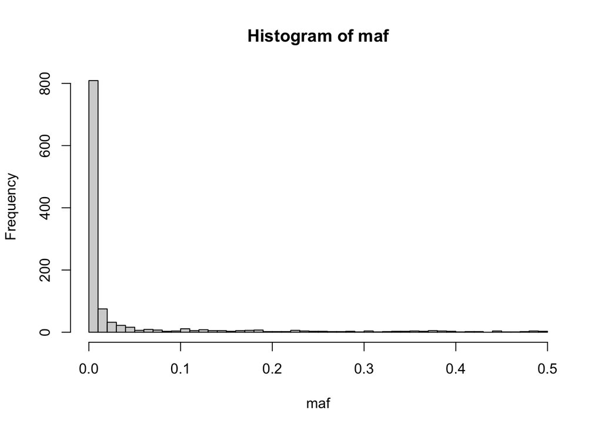

```r
hist(maf, breaks=50)
```

#### Data Filters

We can define a filter on the `gds` object. After using the `seqSetFilter` command, all subsequent reads from the `gds` object are restricted to the selected subset of data, until a new filter is defined or `seqResetFilter` is called to clear the filter.

```r
seqSetFilter(gds, variant.id=91:100, sample.id=sample.id[1:5])
```

```
## # of selected samples: 5
## # of selected variants: 10
```

```r
# only returns data for the filtered variants
seqGetData(gds, "variant.id")
```

```
##  [1]  91  92  93  94  95  96  97  98  99 100
```

#### Genotype Data

Genotype data is stored in a 3-dimensional array, where the first dimension is always length 2 for diploid genotypes. The second and third dimensions are samples and variants, respectively. The values of the array denote alleles: `0` is the reference allele and `1` is the alternate allele. For multiallelic variants, other alternate alleles are represented as integers `> 1`.

```r
geno <- seqGetData(gds, "genotype")
dim(geno)
```

```
## [1]  2  5 10
```

```r
# print the first two variants
geno[,,1:2]
```

```
## , , 1
##
##       sample
## allele [,1] [,2] [,3] [,4] [,5]
##   [1,]    1    1    1    1    1
##   [2,]    1    1    1    1    1
##
## , , 2
##
##       sample
## allele [,1] [,2] [,3] [,4] [,5]
##   [1,]    0    0    0    0    0
##   [2,]    0    1    0    0    1
```

The [SeqVarTools R package](http://bioconductor.org/packages/SeqVarTools) has some additional functions for interacting with SeqArray-format GDS files. There are functions providing more intuitive ways to read in genotypes. What does each of the following functions return?

```r
library(SeqVarTools)

# return genotypes in matrix format
getGenotype(gds)
```

```
##          variant
## sample    91    92    93    94    95    96    97    98    99    100
##   HG00096 "1|1" "0|0" "0|0" "0|0" "0|0" "0|0" "0|0" "1|1" "0|0" "0|0"
##   HG00097 "1|1" "0|1" "0|0" "0|0" "0|0" "0|0" "0|0" "1|0" "0|0" "0|0"
##   HG00099 "1|1" "0|0" "0|0" "0|0" "0|0" "0|0" "0|0" "1|0" "0|0" "0|0"
##   HG00100 "1|1" "0|0" "0|0" "0|0" "0|0" "0|0" "0|0" "0|0" "0|0" "0|0"
##   HG00101 "1|1" "0|1" "0|0" "0|0" "0|0" "0|0" "0|0" "0|0" "0|0" "0|0"
```

```r
getGenotypeAlleles(gds)
```

```
##          variant
## sample    91    92    93    94    95    96    97    98    99    100
##   HG00096 "G|G" "T|T" "G|G" "G|G" "G|G" "A|A" "C|C" "G|G" "C|C" "T|T"
##   HG00097 "G|G" "T|C" "G|G" "G|G" "G|G" "A|A" "C|C" "G|C" "C|C" "T|T"
##   HG00099 "G|G" "T|T" "G|G" "G|G" "G|G" "A|A" "C|C" "G|C" "C|C" "T|T"
##   HG00100 "G|G" "T|T" "G|G" "G|G" "G|G" "A|A" "C|C" "C|C" "C|C" "T|T"
##   HG00101 "G|G" "T|C" "G|G" "G|G" "G|G" "A|A" "C|C" "C|C" "C|C" "T|T"
```

```r
refDosage(gds)
```

```
##          variant
## sample    91 92 93 94 95 96 97 98 99 100
##   HG00096  0  2  2  2  2  2  2  0  2   2
##   HG00097  0  1  2  2  2  2  2  1  2   2
##   HG00099  0  2  2  2  2  2  2  1  2   2
##   HG00100  0  2  2  2  2  2  2  2  2   2
##   HG00101  0  1  2  2  2  2  2  2  2   2
```

```r
altDosage(gds)
```

```
##          variant
## sample    91 92 93 94 95 96 97 98 99 100
##   HG00096  2  0  0  0  0  0  0  2  0   0
##   HG00097  2  1  0  0  0  0  0  1  0   0
##   HG00099  2  0  0  0  0  0  0  1  0   0
##   HG00100  2  0  0  0  0  0  0  0  0   0
##   HG00101  2  1  0  0  0  0  0  0  0   0
```

#### Variant Information

There are functions to extract variant-level information.

```r
# look at reference and alternate alleles
refChar(gds)
```

```
##  [1] "A" "T" "G" "G" "G" "A" "C" "C" "C" "T"
```

```r
altChar(gds)
```

```
##  [1] "G" "C" "A" "A" "A" "G" "T" "G" "A" "C"
```

```r
# data.frame of variant information
variantInfo(gds)
```

```
##    variant.id chr      pos ref alt
## 1          91   1 15461365   A   G
## 2          92   1 15817319   T   C
## 3          93   1 16150840   G   A
## 4          94   1 16272296   G   A
## 5          95   1 16300899   G   A
## 6          96   1 16353896   A   G
## 7          97   1 16414772   C   T
## 8          98   1 16446764   C   G
## 9          99   1 16448267   C   A
## 10        100   1 16699413   T   C
```

We can also return variant information as a `GRanges` object from the [GenomicRanges package](https://bioconductor.org/packages/release/bioc/manuals/GenomicRanges/man/GenomicRanges.pdf). This format for representing sequence data is common across many Bioconductor packages. Chromosome is stored in the `seqnames` column. The `ranges` column has variant position, which can be a single base pair or a range. We will use `GRanges` objects when we analyze sets of variants (e.g. in genes).

```r
# reset the filter to all variants and samples
seqResetFilter(gds)
```

```
## # of selected samples: 1,126
## # of selected variants: 1,120
```

```r
gr <- granges(gds)
gr
```

```
## GRanges object with 1120 ranges and 0 metadata columns:
##        seqnames              ranges strand
##           <Rle>           <IRanges>  <Rle>
##      1        1              970546      *
##      2        1              985900      *
##      3        1             1025045      *
##      4        1             1265550      *
##      5        1             1472676      *
##    ...      ...                 ...    ...
##   1116        1           248715186      *
##   1117        1 248715606-248715610      *
##   1118        1           248761613      *
##   1119        1           248894546      *
##   1120        1           249149558      *
##   -------
##   seqinfo: 1 sequence from an unspecified genome; no seqlengths
```

#### Multi-allelic Variants

We can use the number of alleles present at each variant to identify multi-allelic variants.

```r
# how many alleles for each variant?
n <- seqNumAllele(gds)
table(n)
```

```
## n
##    2    3    4
## 1099   20    1
```

```r
# some variants have more than one alternate allele
multi.allelic <- which(n > 2)
altChar(gds)[multi.allelic]
```

```
##  [1] "GT,G"            "G,T"             "A,T"             "A,T"
##  [5] "ATG,ATGTG"       "C,G"             "A,T"             "C,T"
##  [9] "A,C"             "TAA,T"           "GTTA,GTTT"       "GCC,GCCC,G"
## [13] "A,C"             "A,C"             "A,C"             "CAAGCAT,CGAGCAT"
## [17] "CATTATT,C"       "AT,C"            "TGTGA,C"         "CCATT,CCATTCATT"
## [21] "C,G"
```

#### Close a GDS

Always use the `seqClose` command to close your connection to a GDS file when you are done working with it. Trying to open an already opened GDS will result in an error.

```r
seqClose(gds)
```

### Exercise 1.1 (Data Studio)

Open the GDS file you created above. Set a filter selecting only multi-allelic variants. Inspect the genotypes using the different methods you learned above. Try the `expandedAltDosage` function – what does this return? You can also use the `alleleDosage` method to find dosage for the reference allele and each (i.e. first, second, third) of the alternate alleles separately.

```r
# your solution here
#
#
#
#
#
#
#
#
#
```

### Solution 1.1 (Data Studio)

Open the GDS file you created above. Set a filter selecting only multi-allelic variants. Inspect the genotypes using the different methods you learned above. Try the `expandedAltDosage` function – what does this return? You can also use the `alleleDosage` method to find dosage for the reference allele and each (i.e. first, second, third) of the alternate alleles separately.

```r
# open a connection to the GDS file again
gds <- seqOpen(gdsfile)

# set your filter (we can use the indicator we created for multi.allelic variants from above)
seqSetFilter(gds, variant.sel=multi.allelic)
```

```
## # of selected variants: 21
```

```r
# inspect the genotypes
geno <- seqGetData(gds, "genotype")
dim(geno)
```

```
## [1]    2 1126   21
```

```r
geno[,1:5,1:5]
```

```
## , , 1
##
##       sample
## allele [,1] [,2] [,3] [,4] [,5]
##   [1,]    1    1    0    1    1
##   [2,]    0    1    1    1    1
##
## , , 2
##
##       sample
## allele [,1] [,2] [,3] [,4] [,5]
##   [1,]    0    0    0    0    0
##   [2,]    0    0    0    0    0
##
## , , 3
##
##       sample
## allele [,1] [,2] [,3] [,4] [,5]
##   [1,]    0    0    0    0    0
##   [2,]    0    0    0    0    0
##
## , , 4
##
##       sample
## allele [,1] [,2] [,3] [,4] [,5]
##   [1,]    1    0    0    1    0
##   [2,]    0    0    0    0    1
##
## , , 5
##
##       sample
## allele [,1] [,2] [,3] [,4] [,5]
##   [1,]    0    0    0    0    0
##   [2,]    0    0    0    0    0
```

```r
geno <- getGenotype(gds)
dim(geno)
```

```
## [1] 1126   21
```

```r
head(geno)
```

```
##          variant
## sample    30    69    73    161   162   195   243   253   407   431   434
##   HG00096 "1|0" "0|0" "0|0" "1|0" "0|0" "0|0" "0|0" "0|0" "0|0" "1|0" "0|1"
##   HG00097 "1|1" "0|0" "0|0" "0|0" "0|0" "0|0" "0|0" "0|0" "0|0" "2|2" "0|1"
##   HG00099 "0|1" "0|0" "0|0" "0|0" "0|0" "0|0" "0|0" "0|0" "0|0" "0|0" "1|0"
##   HG00100 "1|1" "0|0" "0|0" "1|0" "0|0" "0|0" "0|0" "0|0" "0|0" "0|2" "0|1"
##   HG00101 "1|1" "0|0" "0|0" "0|1" "0|0" "0|0" "0|0" "0|0" "2|0" "1|1" "0|0"
##   HG00102 "0|1" "0|0" "0|0" "1|0" "0|0" "0|0" "0|0" "0|0" "0|0" "2|2" "0|1"
##          variant
## sample    610   627   645   689   756   765   814   988   1014  1056
##   HG00096 "3|3" "0|0" "0|0" "2|0" "2|2" "2|2" "0|0" "0|0" "0|0" "0|0"
##   HG00097 "1|3" "0|0" "0|0" "0|0" "2|2" "2|2" "0|0" "0|0" "0|0" "0|0"
##   HG00099 "1|3" "0|0" "0|0" "0|0" "2|2" "2|2" "0|0" "0|0" "0|0" "0|0"
##   HG00100 "1|1" "2|0" "0|0" "0|2" "2|2" "2|2" "0|0" "0|0" "0|0" "0|2"
##   HG00101 "3|0" "0|0" "0|0" "2|0" "2|2" "2|2" "0|0" "0|0" "1|0" "0|0"
##   HG00102 "3|3" "0|2" "0|0" "0|0" "2|2" "1|2" "0|0" "0|0" "0|1" "0|2"
```

```r
geno <- getGenotypeAlleles(gds)
head(geno)
```

```
##          variant
## sample    30       69    73    161   162   195   243   253   407   431
##   HG00096 "GT|GTT" "A|A" "G|G" "A|G" "A|A" "A|A" "C|C" "G|G" "T|T" "TAA|TA"
##   HG00097 "GT|GT"  "A|A" "G|G" "G|G" "A|A" "A|A" "C|C" "G|G" "T|T" "T|T"
##   HG00099 "GTT|GT" "A|A" "G|G" "G|G" "A|A" "A|A" "C|C" "G|G" "T|T" "TA|TA"
##   HG00100 "GT|GT"  "A|A" "G|G" "A|G" "A|A" "A|A" "C|C" "G|G" "T|T" "TA|T"
##   HG00101 "GT|GT"  "A|A" "G|G" "G|A" "A|A" "A|A" "C|C" "G|G" "C|T" "TAA|TAA"
##   HG00102 "GTT|GT" "A|A" "G|G" "A|G" "A|A" "A|A" "C|C" "G|G" "T|T" "T|T"
##          variant
## sample    434      610       627   645   689   756               765
##   HG00096 "G|GTTA" "G|G"     "G|G" "G|G" "C|G" "CGAGCAT|CGAGCAT" "C|C"
##   HG00097 "G|GTTA" "GCC|G"   "G|G" "G|G" "G|G" "CGAGCAT|CGAGCAT" "C|C"
##   HG00099 "GTTA|G" "GCC|G"   "G|G" "G|G" "G|G" "CGAGCAT|CGAGCAT" "C|C"
##   HG00100 "G|GTTA" "GCC|GCC" "C|G" "G|G" "G|C" "CGAGCAT|CGAGCAT" "C|C"
##   HG00101 "G|G"    "G|GC"    "G|G" "G|G" "C|G" "CGAGCAT|CGAGCAT" "C|C"
##   HG00102 "G|GTTA" "G|G"     "G|C" "G|G" "G|G" "CGAGCAT|CGAGCAT" "CATTATT|C"
##          variant
## sample    814     988           1014      1056
##   HG00096 "CT|CT" "CGTGA|CGTGA" "C|C"     "A|A"
##   HG00097 "CT|CT" "CGTGA|CGTGA" "C|C"     "A|A"
##   HG00099 "CT|CT" "CGTGA|CGTGA" "C|C"     "A|A"
##   HG00100 "CT|CT" "CGTGA|CGTGA" "C|C"     "A|G"
##   HG00101 "CT|CT" "CGTGA|CGTGA" "CCATT|C" "A|A"
##   HG00102 "CT|CT" "CGTGA|CGTGA" "C|CCATT" "A|G"
```

```r
# count of *each* of the alternate alleles separately
# returns multiple columns per variant
dos <- expandedAltDosage(gds)
head(dos)
```

```
##          variant
## sample    30 30 69 69 73 73 161 161 162 162 195 195 243 243 253 253 407 407 431
##   HG00096  1  0  0  0  0  0   1   0   0   0   0   0   0   0   0   0   0   0   1
##   HG00097  2  0  0  0  0  0   0   0   0   0   0   0   0   0   0   0   0   0   0
##   HG00099  1  0  0  0  0  0   0   0   0   0   0   0   0   0   0   0   0   0   0
##   HG00100  2  0  0  0  0  0   1   0   0   0   0   0   0   0   0   0   0   0   0
##   HG00101  2  0  0  0  0  0   1   0   0   0   0   0   0   0   0   0   0   1   2
##   HG00102  1  0  0  0  0  0   1   0   0   0   0   0   0   0   0   0   0   0   0
##          variant
## sample    431 434 434 610 610 610 627 627 645 645 689 689 756 756 765 765 814
##   HG00096   0   1   0   0   0   2   0   0   0   0   0   1   0   2   0   2   0
##   HG00097   2   1   0   1   0   1   0   0   0   0   0   0   0   2   0   2   0
##   HG00099   0   1   0   1   0   1   0   0   0   0   0   0   0   2   0   2   0
##   HG00100   1   1   0   2   0   0   0   1   0   0   0   1   0   2   0   2   0
##   HG00101   0   0   0   0   0   1   0   0   0   0   0   1   0   2   0   2   0
##   HG00102   2   1   0   0   0   2   0   1   0   0   0   0   0   2   1   1   0
##          variant
## sample    814 988 988 1014 1014 1056 1056
##   HG00096   0   0   0    0    0    0    0
##   HG00097   0   0   0    0    0    0    0
##   HG00099   0   0   0    0    0    0    0
##   HG00100   0   0   0    0    0    0    1
##   HG00101   0   0   0    1    0    0    0
##   HG00102   0   0   0    1    0    0    1
```

```r
# count of the reference allele
dos <- alleleDosage(gds, n=0)
head(dos)
```

```
##          variant
## sample    30 69 73 161 162 195 243 253 407 431 434 610 627 645 689 756 765 814
##   HG00096  1  2  2   1   2   2   2   2   2   1   1   0   2   2   1   0   0   2
##   HG00097  0  2  2   2   2   2   2   2   2   0   1   0   2   2   2   0   0   2
##   HG00099  1  2  2   2   2   2   2   2   2   2   1   0   2   2   2   0   0   2
##   HG00100  0  2  2   1   2   2   2   2   2   1   1   0   1   2   1   0   0   2
##   HG00101  0  2  2   1   2   2   2   2   1   0   2   1   2   2   1   0   0   2
##   HG00102  1  2  2   1   2   2   2   2   2   0   1   0   1   2   2   0   0   2
##          variant
## sample    988 1014 1056
##   HG00096   2    2    2
##   HG00097   2    2    2
##   HG00099   2    2    2
##   HG00100   2    2    1
##   HG00101   2    1    2
##   HG00102   2    1    1
```

```r
# count of the first alternate allele
dos <- alleleDosage(gds, n=1)
head(dos)
```

```
##          variant
## sample    30 69 73 161 162 195 243 253 407 431 434 610 627 645 689 756 765 814
##   HG00096  1  0  0   1   0   0   0   0   0   1   1   0   0   0   0   0   0   0
##   HG00097  2  0  0   0   0   0   0   0   0   0   1   1   0   0   0   0   0   0
##   HG00099  1  0  0   0   0   0   0   0   0   0   1   1   0   0   0   0   0   0
##   HG00100  2  0  0   1   0   0   0   0   0   0   1   2   0   0   0   0   0   0
##   HG00101  2  0  0   1   0   0   0   0   0   2   0   0   0   0   0   0   0   0
##   HG00102  1  0  0   1   0   0   0   0   0   0   1   0   0   0   0   0   1   0
##          variant
## sample    988 1014 1056
##   HG00096   0    0    0
##   HG00097   0    0    0
##   HG00099   0    0    0
##   HG00100   0    0    0
##   HG00101   0    1    0
##   HG00102   0    1    0
```

```r
# count of the third alternate allele
dos <- alleleDosage(gds, n=3)
head(dos)
```

```
##          variant
## sample    30 69 73 161 162 195 243 253 407 431 434 610 627 645 689 756 765 814
##   HG00096  0  0  0   0   0   0   0   0   0   0   0   2   0   0   0   0   0   0
##   HG00097  0  0  0   0   0   0   0   0   0   0   0   1   0   0   0   0   0   0
##   HG00099  0  0  0   0   0   0   0   0   0   0   0   1   0   0   0   0   0   0
##   HG00100  0  0  0   0   0   0   0   0   0   0   0   0   0   0   0   0   0   0
##   HG00101  0  0  0   0   0   0   0   0   0   0   0   1   0   0   0   0   0   0
##   HG00102  0  0  0   0   0   0   0   0   0   0   0   2   0   0   0   0   0   0
##          variant
## sample    988 1014 1056
##   HG00096   0    0    0
##   HG00097   0    0    0
##   HG00099   0    0    0
##   HG00100   0    0    0
##   HG00101   0    0    0
##   HG00102   0    0    0
```

Don’t forget to close your connection to the GDS file when you’re done!

```r
seqClose(gds)
```

### Exercise 1.2 (Application)

The Apps on the BioData Catalyst powered by Seven Bridges platform allow you to easily scale up cloud computing to running analyses on all chromosomes genome-wide and with larger samples. Use the `VCF to GDS Converter` app to convert the example 1000 Genomes files into GDS files. The steps to perform this analysis are as follows:

- Copy the app to your project if it is not already there:
  - Click: Public Gallery > Apps > Browse
  - Search for `VCF to GDS Converter`
  - Click: Copy > Select your project > Copy
- Run the analysis in your project:
  - Click: Apps > `VCF to GDS Converter` > Run
  - Specify the Inputs:
    - Variants Files: `1KG_phase3_subset_chr<CHR>.vcf.gz` (select all 22 chromosomes)
  - Specify the App Settings:
    - check GDS: No
  - Click: Run

The analysis will take a few minutes to run. You can find your analysis in the Tasks menu of your Project. Use the “View stats & logs” button to check on the status of your tasks. The output of this analysis will be a set of 22 GDS files, one per chromosome.

You can find the expected output of this analysis by looking at the existing task `01. Convert 1KG VCF to GDS` in the Tasks menu of your Project.